# Practical Machine Learning Final Project

Rohit Joshi

July 7, 2017

# Practical Machine Learning: Final Project

The purpose of this analysis is to build a human activity recognition algorithm. Accelerometers were placed on six individuals who performed bicep curls either correctly or incorrectly. Using approximately 160 variables that were collected from the accelerometers, we will build an algorithm for predicting whether an individual correctly or incorrectly performed the exercise. The source data is available (here)[http://groupware.les.inf.puc-rio.br/har].

## Preparing the data

### Importing packages

```r
library(caret)
library(gbm)
```

```r
library(rpart)
library(rpart.plot)
library(randomForest)
library(munsell)
library(rattle)
```

### Loading the data

```r
download.file("https://d396qusza40orc.cloudfront.net/predmachlearn/pml-training.csv","pml_training.csv")
pml_training<-read.csv("pml_training.csv", na.strings=c("NA",""))
download.file("https://d396qusza40orc.cloudfront.net/predmachlearn/pml-testing.csv","pml_test.csv")
pml_test<-read.csv("pml_test.csv", na.strings=c("NA",""))
```

### Cleaning data

```r
#Remove variables with NA values
pml_training<-pml_training[,colSums(is.na(pml_training))==0]
pml_test<-pml_test[,colSums(is.na(pml_test))==0]
#remove unnecessary variables
pml_training<-pml_training[,-c(1,3:7)]
pml_test<-pml_test[,-c(1,3:7)]
#code user names categorically
pml_training$carlitos<-ifelse(pml_training$user_name=='carlitos',1,0)
pml_training$charles<-ifelse(pml_training$user_name=='charles',1,0)
pml_training$eurico<-ifelse(pml_training$user_name=='eurico',1,0)
pml_training$eurico<-ifelse(pml_training$user_name=='jeremy',1,0)
pml_training$pedro<-ifelse(pml_training$user_name=='pedro',1,0)
pml_test$carlitos<-ifelse(pml_test$user_name=='carlitos',1,0)
pml_test$charles<-ifelse(pml_test$user_name=='charles',1,0)
pml_test$eurico<-ifelse(pml_test$user_name=='eurico',1,0)
pml_test$eurico<-ifelse(pml_test$user_name=='jeremy',1,0)
pml_test$pedro<-ifelse(pml_test$user_name=='pedro',1,0)
```

### Partitioning data

Although we already have a separate training and test set, we need to further split the training data into a training and validation set so that we can estimate “out-of-sample” error. Typically 70% of the training data is allocated to remain in the training set, and 30% becomes validation.

```r
set.seed(1338)
inTrain<-createDataPartition(pml_training$classe,p=0.7,list=FALSE)
train<-pml_training[inTrain,]
validation<-pml_training[-inTrain,]
test<-pml_test
```

## Building the model

### Regression model

Building the model:

```r
set.seed(1338)
regression_control<-trainControl(method = "repeatedcv", number = 10, repeats = 1)
regression_model<-train(classe~.,data=train,method="gbm", trControl=regression_control,verbose=FALSE)
```

Testing the data on our validation data:

```r
regression_predict<-predict(regression_model,newdata=validation)
regression_cm<-confusionMatrix(regression_predict,validation$classe)
regression_cm
```

```
## Confusion Matrix and Statistics
##
##           Reference
## Prediction    A    B    C    D    E
##          A 1646   34    0    3    3
##          B   20 1068   35    3   17
##          C    6   35  970   36    4
##          D    2    2   15  913   15
##          E    0    0    6    9 1043
##
## Overall Statistics
##
##                Accuracy : 0.9584
##                  95% CI : (0.9529, 0.9633)
##     No Information Rate : 0.2845
##     P-Value [Acc > NIR] : < 2.2e-16
##
##                   Kappa : 0.9473
##  Mcnemar's Test P-Value : 1.341e-05
##
## Statistics by Class:
##
##                      Class: A Class: B Class: C Class: D Class: E
## Sensitivity            0.9833   0.9377   0.9454   0.9471   0.9640
## Specificity            0.9905   0.9842   0.9833   0.9931   0.9969
## Pos Pred Value         0.9763   0.9344   0.9229   0.9641   0.9858
## Neg Pred Value         0.9933   0.9850   0.9884   0.9897   0.9919
## Prevalence             0.2845   0.1935   0.1743   0.1638   0.1839
## Detection Rate         0.2797   0.1815   0.1648   0.1551   0.1772
## Detection Prevalence   0.2865   0.1942   0.1786   0.1609   0.1798
## Balanced Accuracy      0.9869   0.9609   0.9644   0.9701   0.9804
```

### Decision tree

Building the model:

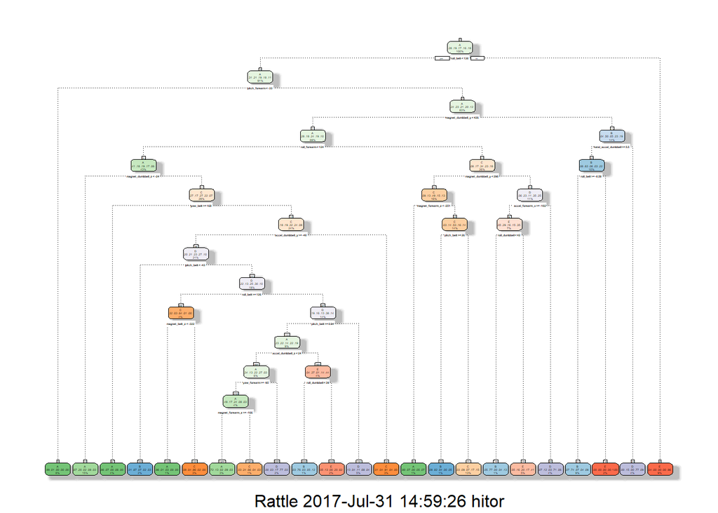

```r
set.seed(1338)
decision_tree_model <- rpart(classe ~ ., data=train, method="class")
fancyRpartPlot(decision_tree_model)
```

Testing the data on our validation data:

```r
decision_tree_predict <- predict(decision_tree_model, validation, type = "class")
decision_tree_matrix <- confusionMatrix(decision_tree_predict, validation$classe)
decision_tree_matrix
```

```
## Confusion Matrix and Statistics
##
##           Reference
## Prediction    A    B    C    D    E
##          A 1478  238   28  105   47
##          B   59  635   61   39   66
##          C   40  118  798  139  115
##          D   50   79   73  588   57
##          E   47   69   66   93  797
##
## Overall Statistics
##
##                Accuracy : 0.73
##                  95% CI : (0.7185, 0.7413)
##     No Information Rate : 0.2845
##     P-Value [Acc > NIR] : < 2.2e-16
##
##                   Kappa : 0.657
##  Mcnemar's Test P-Value : < 2.2e-16
##
## Statistics by Class:
##
##                      Class: A Class: B Class: C Class: D Class: E
## Sensitivity            0.8829   0.5575   0.7778  0.60996   0.7366
## Specificity            0.9007   0.9526   0.9152  0.94737   0.9427
## Pos Pred Value         0.7795   0.7384   0.6595  0.69421   0.7435
## Neg Pred Value         0.9509   0.8997   0.9512  0.92537   0.9408
## Prevalence             0.2845   0.1935   0.1743  0.16381   0.1839
## Detection Rate         0.2511   0.1079   0.1356  0.09992   0.1354
## Detection Prevalence   0.3222   0.1461   0.2056  0.14393   0.1822
## Balanced Accuracy      0.8918   0.7550   0.8465  0.77866   0.8397
```

### Random Forest

Building the model:

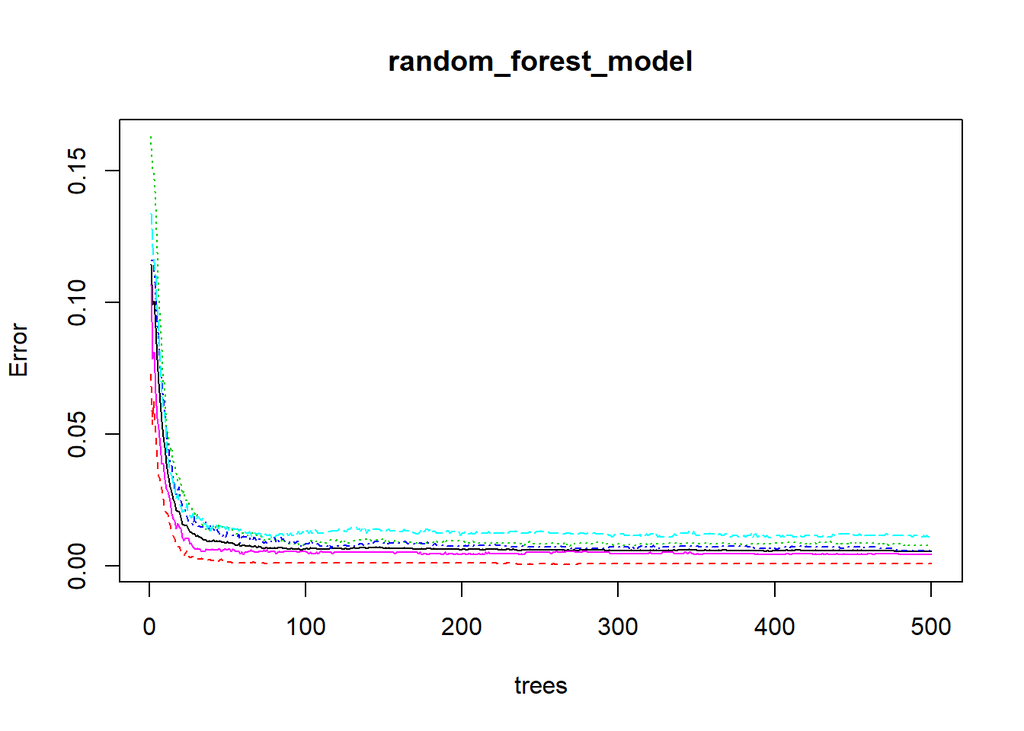

```r
random_forest_model <- randomForest(classe ~ ., data=train)
plot(random_forest_model)
```

```r
random_forest_predict <- predict(random_forest_model, validation, type = "class")
random_forest_matrix <- confusionMatrix(random_forest_predict, validation$classe)
random_forest_matrix
```

```
## Confusion Matrix and Statistics
##
##           Reference
## Prediction    A    B    C    D    E
##          A 1674    7    0    0    0
##          B    0 1131   10    0    0
##          C    0    1 1016    8    0
##          D    0    0    0  956    3
##          E    0    0    0    0 1079
##
## Overall Statistics
##
##                Accuracy : 0.9951
##                  95% CI : (0.9929, 0.9967)
##     No Information Rate : 0.2845
##     P-Value [Acc > NIR] : < 2.2e-16
##
##                   Kappa : 0.9938
##  Mcnemar's Test P-Value : NA
##
## Statistics by Class:
##
##                      Class: A Class: B Class: C Class: D Class: E
## Sensitivity            1.0000   0.9930   0.9903   0.9917   0.9972
## Specificity            0.9983   0.9979   0.9981   0.9994   1.0000
## Pos Pred Value         0.9958   0.9912   0.9912   0.9969   1.0000
## Neg Pred Value         1.0000   0.9983   0.9979   0.9984   0.9994
## Prevalence             0.2845   0.1935   0.1743   0.1638   0.1839
## Detection Rate         0.2845   0.1922   0.1726   0.1624   0.1833
## Detection Prevalence   0.2856   0.1939   0.1742   0.1630   0.1833
## Balanced Accuracy      0.9992   0.9954   0.9942   0.9955   0.9986
```

### Conclusion

The random forest model is the most accurate, followed by the boosted regression model. The decision tree model doesn’t do so well in this case. We’ll go ahead with the random forest approach, and finish off by predicting on our test set using the random forest model.

```r
test_prediction<-predict(random_forest_model,test,type="class")
test_prediction
```

[output not shown]